## PREGUNTA 1

```r
# Leemos los datos del CSV
datos <- read.csv2("Dataset PE1.csv")

# Mostramos los datos iniciales
head(datos)
```

```
##   ID SEXO          EDAD   SHAMPOO NIVEL_3 NIVEL_6 NIVEL_9 NIVEL_12 PERCEPCION_3
## 1  1    F         40-49 ChaoCaspa  10.183   9.970   9.410    9.604           -1
## 2  2    F         50-59 ChaoCaspa   9.814  10.261   9.886    9.723           -1
## 3  3    F         60-69 ChaoCaspa  10.279  10.362   9.366    8.446           -1
## 4  4    F 70 o superior ChaoCaspa  10.024   9.512  10.524    9.842           -1
## 5  5    F         40-49   Placebo   9.999  10.319  10.344   10.764           -1
## 6  6    F         50-59   Placebo  10.693  10.267  10.638   10.773           -1
##   PERCEPCION_6 PERCEPCION_9 PERCEPCION_12
## 1           -1           -1            -2
## 2            1            0            -1
## 3           -1            1             3
## 4            1            1             2
## 5           -1            0            -1
## 6           -1            0             1
```

Debido a que se están midiendo cuatro grupos independientes, que en este caso corresponden a los usuarios de ChaoCaspa de diferentes edades (40-49, 50-59, 60-69, 70 o superior), y además la escala del H2O2 en el cabello de los participantes presenta una escala de intervalos iguales. Debido a estos datos, la prueba seleccionada preliminarmente es el método de ANOVA para muestras independientes. Para realizarla correctamente, es necesario verificar que las condiciones se cumplan correctamente.

- Observaciones independientes: Debido al formato del estudio, se puede deducir razonablemente que las observaciones son independientes, pues corresponden a distintas personas utilizando un producto para el cabello.
- La variable medida corresponde a una escala de intervalos iguales: De la misma forma que se mencionó en el análisis preliminar, la medida de microgramos de H2O2 es de intervalos iguales.
- Las observaciones provienen de una distribución normal: Para esta condición, la solución escogida es realizar un test test de Shapiro-Wilk en cada uno de los grupos.

```r
datos_filtradosP1 <- datos %>% filter(SEXO == "M") %>% filter(SHAMPOO == "ChaoCaspa") %>% select(ID, SEXO, EDAD, SHAMPOO, NIVEL_3)
datos_filtradosP1[["ID"]] <- factor(datos_filtradosP1[["ID"]])
datos_filtradosP1[["EDAD"]] <- factor(datos_filtradosP1[["EDAD"]])

head(datos_filtradosP1)
```

```
##   ID SEXO          EDAD   SHAMPOO NIVEL_3
## 1  9    M         40-49 ChaoCaspa  13.222
## 2 10    M         50-59 ChaoCaspa  13.471
## 3 11    M         60-69 ChaoCaspa  12.790
## 4 12    M 70 o superior ChaoCaspa  12.354
## 5 25    M         40-49 ChaoCaspa  12.632
## 6 26    M         50-59 ChaoCaspa  13.306
```

```r
edad40 <- datos_filtradosP1 %>% filter(EDAD == "40-49")
edad50 <- datos_filtradosP1 %>% filter(EDAD == "50-59")
edad60 <- datos_filtradosP1 %>% filter(EDAD == "60-69")
edad70 <- datos_filtradosP1 %>% filter(EDAD == "70 o superior")

normalidad40 <- shapiro.test(edad40$NIVEL_3)
print(normalidad40)
```

```
##
##  Shapiro-Wilk normality test
##
## data:  edad40$NIVEL_3
## W = 0.99585, p-value = 0.3755
```

```r
normalidad50 <- shapiro.test(edad50$NIVEL_3)
print(normalidad50)
```

```
##
##  Shapiro-Wilk normality test
##
## data:  edad50$NIVEL_3
## W = 0.9979, p-value = 0.9032
```

```r
normalidad60 <- shapiro.test(edad60$NIVEL_3)
print(normalidad60)
```

```
##
##  Shapiro-Wilk normality test
##
## data:  edad60$NIVEL_3
## W = 0.99553, p-value = 0.3115
```

```r
normalidad70 <- shapiro.test(edad70$NIVEL_3)
print(normalidad70)
```

```
##
##  Shapiro-Wilk normality test
##
## data:  edad70$NIVEL_3
## W = 0.99602, p-value = 0.4139
```

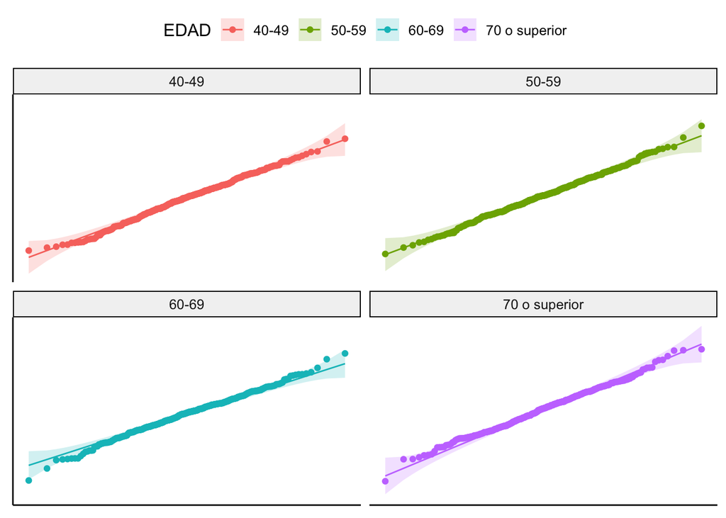

```r
g <- ggqqplot(datos_filtradosP1, x = "NIVEL_3", y = "EDAD", color = "EDAD")

g <- g + facet_wrap(~ EDAD)
g <- g + rremove("x.ticks") + rremove("x.text")
g <- g + rremove("y.ticks") + rremove("y.text")
g <- g + rremove("axis.title")
print(g)
```

Recordando que esta prueba posee una hipótesis nula que implica que las muestras provienen de una distribución normal, se obtuvo que todos los casos presentan un p-valor notablemente mayor al nivel de significancia seleccionado. Por ende, se puede concluir con seguridad que todas las observaciones provienen de una distribución normal. Finalmente, queda verificar la condición de homocedasticidad. Es decir, si las muestras provienen de poblaciones distintas, todas deben tener la misma varianza. Para esto, en primera instancia se utiliza la función de R EZAnova, que, además de entregar los resultados de la prueba de ANOVA, también incluye un test de Levene para la condición buscada.

```r
alfa <- 0.05

omnibus <- ezANOVA(
  data = datos_filtradosP1,
  dv = NIVEL_3, between = EDAD, wid = ID,
  return_aov = TRUE
)
```

```
## Coefficient covariances computed by hccm()
```

```r
cat("Resultado de la prueba de Levene:\n")
```

```
## Resultado de la prueba de Levene:
```

```r
print(omnibus[2])
```

```
## $`Levene's Test for Homogeneity of Variance`
##   DFn  DFd       SSn      SSd      F          p p<.05
## 1   3 1596 0.5997395 147.6726 2.1606 0.09082525
```

El test de Levene entrega un p-valor de 0.09, el cual está peligrosamente cercano al nivel de significancia dado, pero que sigue siendo mayor, por lo que se puede concluir que la homocedasticidad se cumple, sin embargo, se recomienda al químico farmacéutico realizar otra prueba con una muestra más grande.

Adicionalmente, se realizó una prueba adicional de varianzas, analizando la relación entre la máxima y mínima varianza. Como el resultado entrega 1.24, por lo que, al ser menor que 1.5, se posee otra verificación adicional de la condición, permitiendo, finalmente, utilizar la prueba de ANOVA.

```r
varianza_por_edad <- datos_filtradosP1 %>%
  group_by(EDAD) %>%
  summarise(varianza_muestral = var(NIVEL_3, na.rm = TRUE))

# Mostrar el resultado
print(varianza_por_edad)
```

```
## # A tibble: 4 × 2
##   EDAD          varianza_muestral
##   <fct>                     <dbl>
## 1 40-49                     0.258
## 2 50-59                     0.253
## 3 60-69                     0.214
## 4 70 o superior             0.264
```

```r
# Calcular la razón entre la máxima y mínima varianza muestral
max_var <- max(varianza_por_edad$varianza_muestral)
min_var <- min(varianza_por_edad$varianza_muestral)
razon_varianza <- max_var / min_var

print(razon_varianza)
```

```
## [1] 1.233987
```

AL realizar el test de ANOVA, se tienen las siguientes hipótesis:

- H0: No existe una diferencia entre los microgramos de H2O2 entre los casos de distintas edades que utilizaron ChaoCaspa.
- HA: Sí existe una diferencia entre los microgramos de H2O2 entre los casos de distintas edades que utilizaron ChaoCaspa

```r
print(summary(omnibus[["aov"]]))
```

```
##               Df Sum Sq Mean Sq F value Pr(>F)
## EDAD           3   20.9   6.971   28.21 <2e-16 ***
## Residuals   1596  394.3   0.247
## ---
## Signif. codes:  0 '***' 0.001 '**' 0.01 '*' 0.05 '.' 0.1 ' ' 1
```

Con un p-valor obtenido muchísimo menor que el nivel de significancia, entonces se puede rechazar la hipótesis nula y aceptar la hipótesis alternativa, concluyendo que existen diferencias entre los grupos de distintas edades.

Ahora, para determinar en cuáles grupos se encuentran diferencias, se realiza un análisis POST-HOC utilizando la prueba HSD de Tukey.

```r
post_hoc <- TukeyHSD(omnibus[["aov"]], which = "EDAD",
                     ordered = TRUE, conf.level = 1 - alfa)
print(post_hoc)
```

```
##   Tukey multiple comparisons of means
##     95% family-wise confidence level
##     factor levels have been ordered
##
## Fit: aov(formula = formula(aov_formula), data = data)
##
## $EDAD
##                          diff         lwr       upr     p adj
## 50-59-40-49         0.0728725 -0.01752062 0.1632656 0.1623186
## 60-69-40-49         0.1818600  0.09146688 0.2722531 0.0000015
## 70 o superior-40-49 0.3025500  0.21215688 0.3929431 0.0000000
## 60-69-50-59         0.1089875  0.01859438 0.1993806 0.0105789
## 70 o superior-50-59 0.2296775  0.13928438 0.3200706 0.0000000
## 70 o superior-60-69 0.1206900  0.03029688 0.2110831 0.0034159
```

```r
g_efecto <- ezPlot(data = datos_filtradosP1, x = EDAD,
                   dv = NIVEL_3, wid = ID, between = EDAD,
                   y_lab = " Micromolares presentes en el cuero cabelludo [uM]")
```

```
## Coefficient covariances computed by hccm()
```

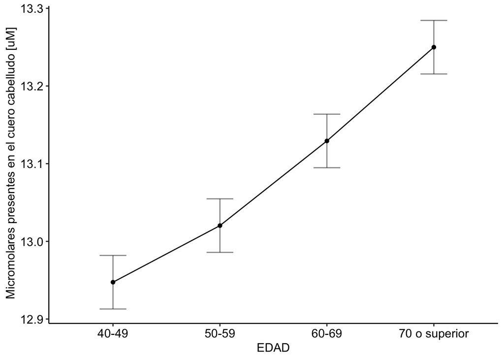

```r
g_efecto <- g_efecto + theme_pubr()
print(g_efecto)
```

A partir de los resultados, se concluye que existen diferencias en las edades de 60-69 a 40-49, 70 o superior a 40-49, 60-69 a 50-59, 70 o superior a 50-59, 70 o superior a 60-69. Esto tambien es comprobable gracias al gráfico mostrado debido a que se logra notar como los datos comienzan a aumentar a medida que aumenta la edad, con la única cercania entre los datos de 50-59 a 40-49.

Concluyendo, se puede determinar con un 95% de confianza que sí existe una diferencia entre los niveles de H2O2 de los hombres que utilizaron ChaoCaspa entre los distintos grupos etarios, por lo que el producto sí afecta de manera distinta según la edad de la persona que lo utiliza. Sin embargo, debido a la fragilidad del test de homocedasticidad, se recomienda utilizar muestras de mayor tamaño, para asegurar la fiabilidad de los resultados

## Pregunta 2

Para la pregunta solicitada, se deben analizar los efectos en las mujeres que usan el placebo en diferentes momentos (3 meses y 6 meses de uso), comparando su percepción del efecto del producto. Hay que recordar que medida de percepción está en una escala de Likert, la cual no posee intervalos iguales entre sus valores, por lo que las pruebas típicas no serán suficientes. Adicionalmente, como se está comparando la percepción en las mismas mujeres, pero en distintos tiempos totales de uso del producto, las muestras se encuentran correlacionadas. Adicionalmente, no podemos asumir que los datos provienen de una distribución normal.

```r
datos_filtradosP2 <- datos %>% filter(SEXO == "F") %>% filter(SHAMPOO == "Placebo") %>% select(ID, SEXO, SHAMPOO, PERCEPCION_3, PERCEPCION_6)

head(datos_filtradosP2)
```

```
##   ID SEXO SHAMPOO PERCEPCION_3 PERCEPCION_6
## 1  5    F Placebo           -1           -1
## 2  6    F Placebo           -1           -1
## 3  7    F Placebo           -1           -2
## 4  8    F Placebo           -1           -1
## 5 21    F Placebo            2            2
## 6 22    F Placebo            2            2
```

Debido a estos antecedentes, la prueba preliminarmente escogida es la prueba de rangos con signo del Wilcoxon. La prueba normal no sería indicada, pues las muestras no son independientes.

Para esta prueba, se deben cumplir dos condiciones principales:

- Las observaciones de la muestras deben provenir de una muestra independiente, y deben estar correlacionadas: Como se mencionó anteriormente, por la naturaleza del estudio, esta condición ya está verificada
- La escala de medida debe ser por lo menos, ordinal. En este caso, como la medida es una escala de Likert, se puede determinar una jerarquía en los puntajes.

```r
alfa <- 0.05

# Hacer la prueba de wilcoxon de signos
prueba <- wilcox.test(datos_filtradosP2$PERCEPCION_3, datos_filtradosP2$PERCEPCION_6,paired = TRUE, alternative = "two.sided", conf.level = 1 - alfa)
print(prueba)
```

```
##
##  Wilcoxon signed rank test with continuity correction
##
## data:  datos_filtradosP2$PERCEPCION_3 and datos_filtradosP2$PERCEPCION_6
## V = 280884, p-value = 0.6001
## alternative hypothesis: true location shift is not equal to 0
```

A partir de la prueba seleccionada, con un nivel de significancia de 0.05, y un p-valor mucho más alto que el alfa seleccionado, no se logra rechazar la hipótesis nula, concluyendo con un 95% de confianza que no existe suficiente evidencia para demostrar que las mujeres sienten una diferencia significativa entre los tres y seis meses de utilizar el producto placebo.